# 第13回 強化学習の店長を、本当に入れてよいか

## 計算する版の出口：閉店からの逆算

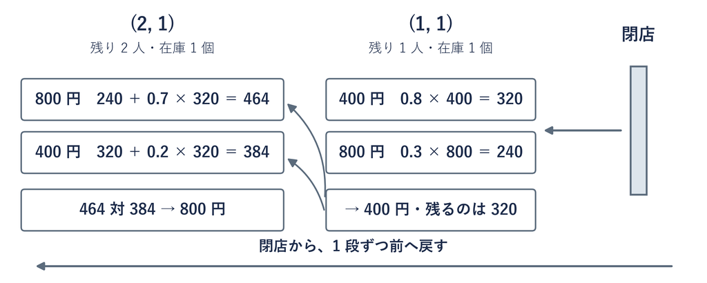

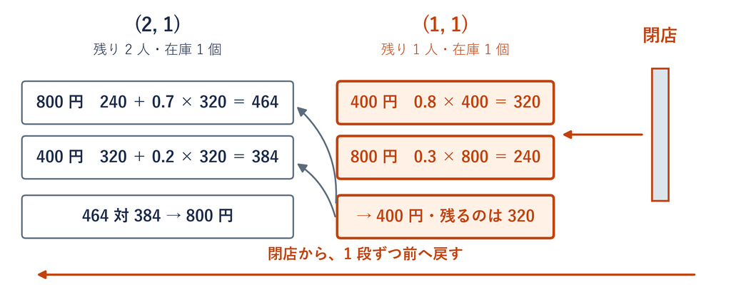

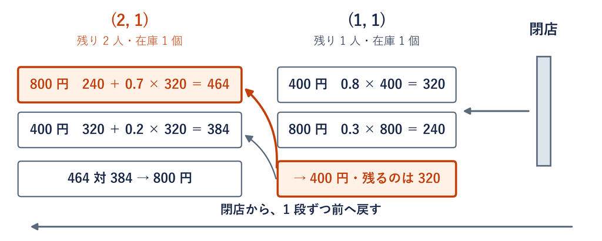

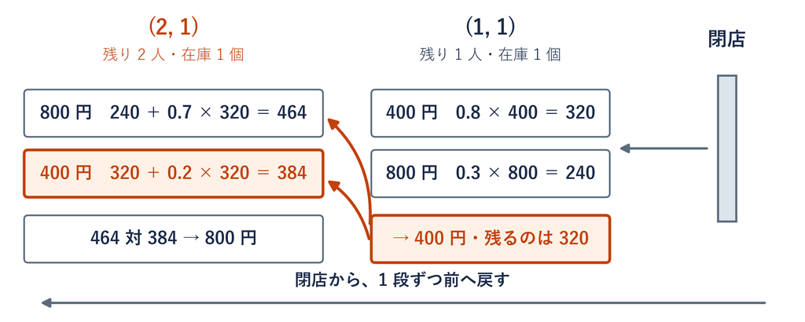

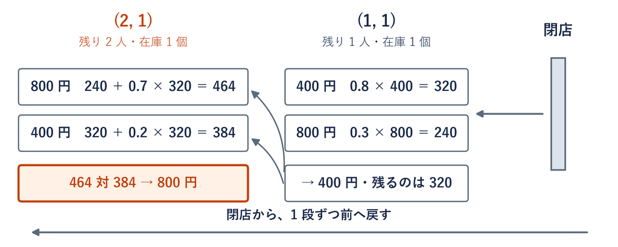

**後ろから決めると、前が決まる**

ここで出るのは、当てた割合のもとでの最善

## 同じ場面 (2, 1) の店長

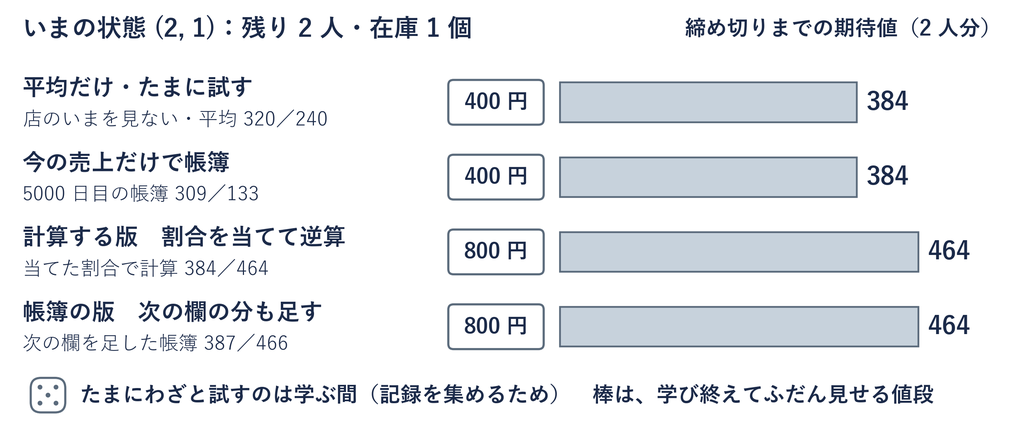

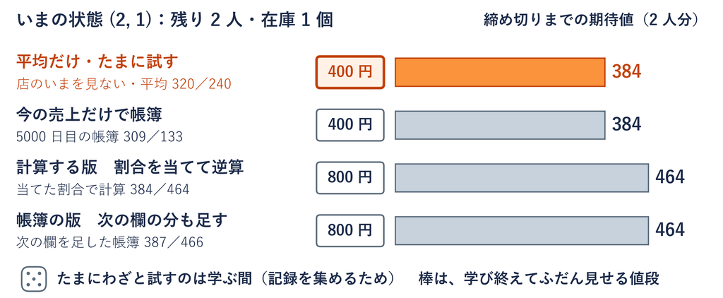

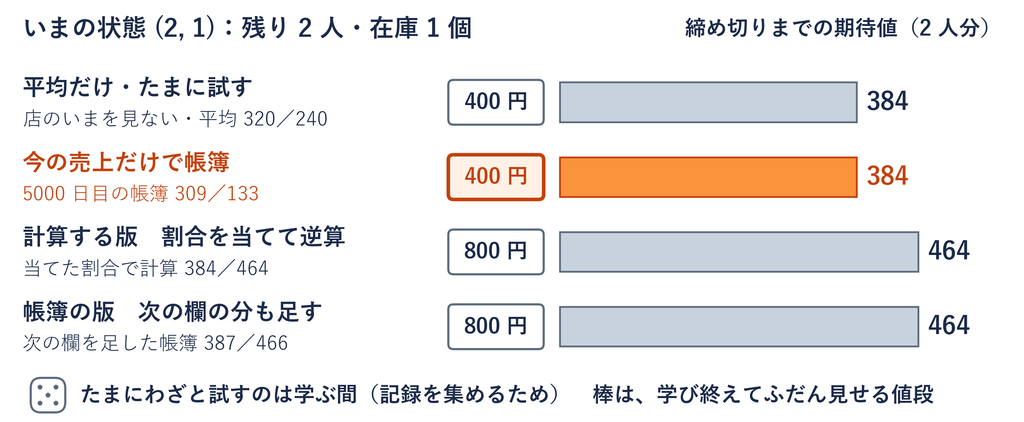

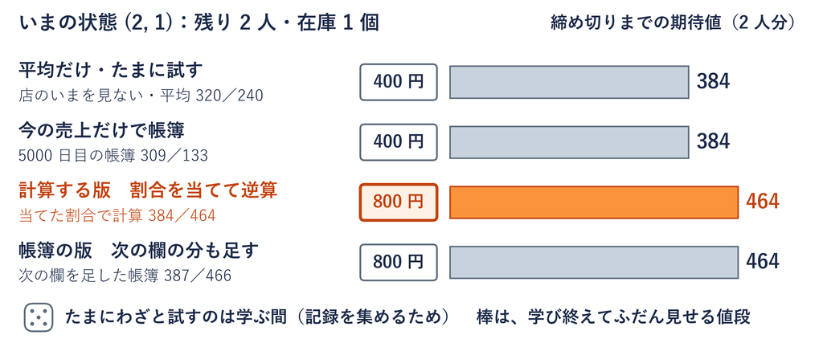

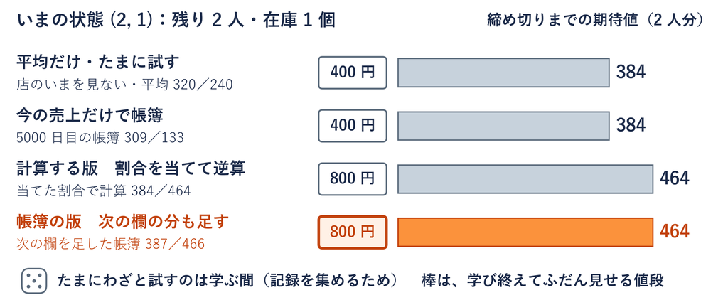

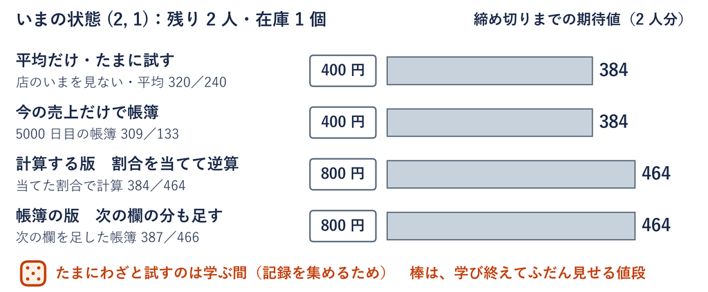

違いは 1 つ：先の数を、割合で計算するか、経験から持ってくるか

## 人も店長も同じ輪

人（教室の美人投票）

2026年度のデータ

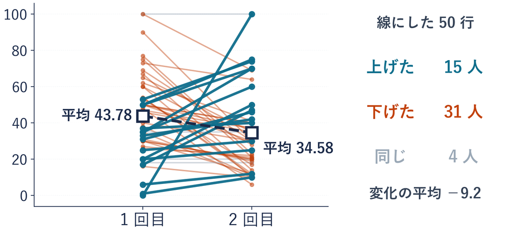

1 回目の結果を見て、2 回目の数を選んだ

店長（コードの代役）

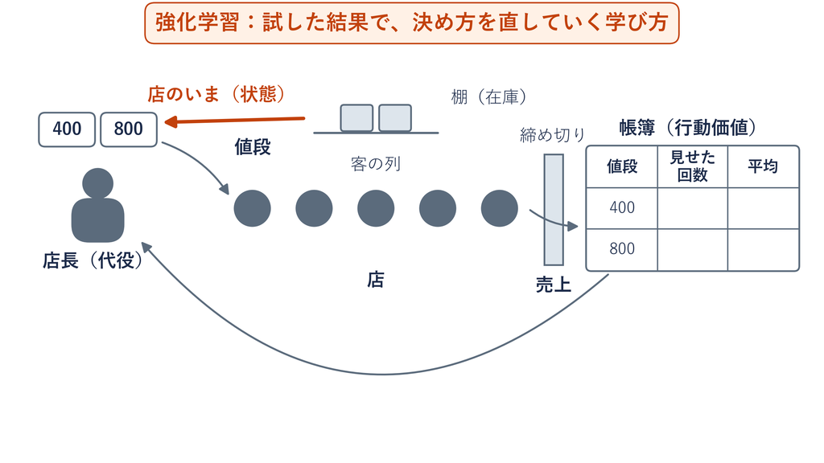

売上を見て、値段の決め方を直す

結果を見て、次の選び方を直す。人も店長も同じ輪

## まとめ

疑問 強化学習とは、何をしていた？

**試した結果で、決め方を直していく。**  
割合を当てて決めることも、試した結果で直すこともできる

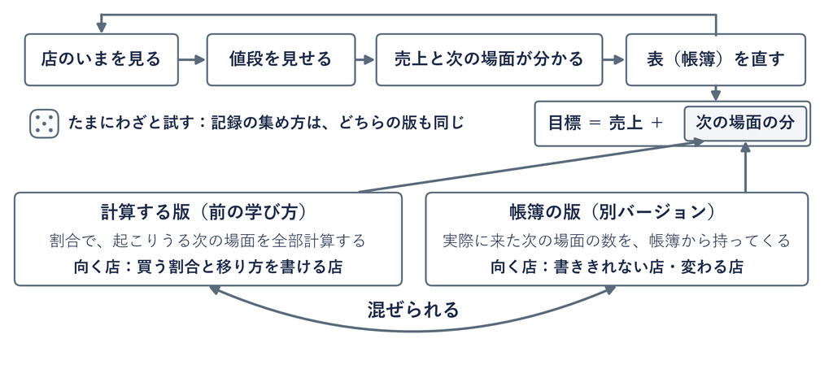

経済プログラミング特論II

第13回・開店 54 日目 — Topic02

入れる前に確かめる

比べる相手と天井を、先に決める

## 学生の確かめ方

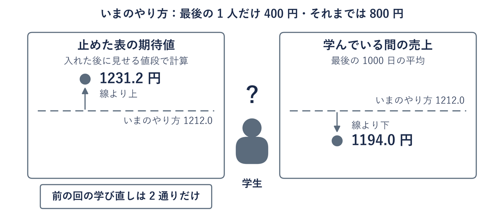

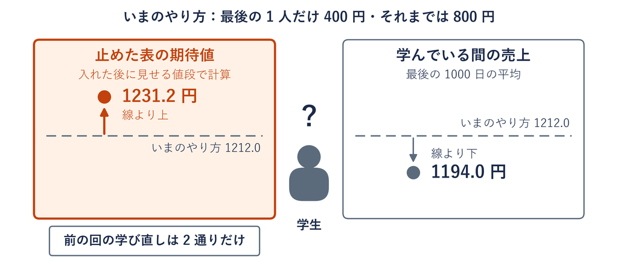

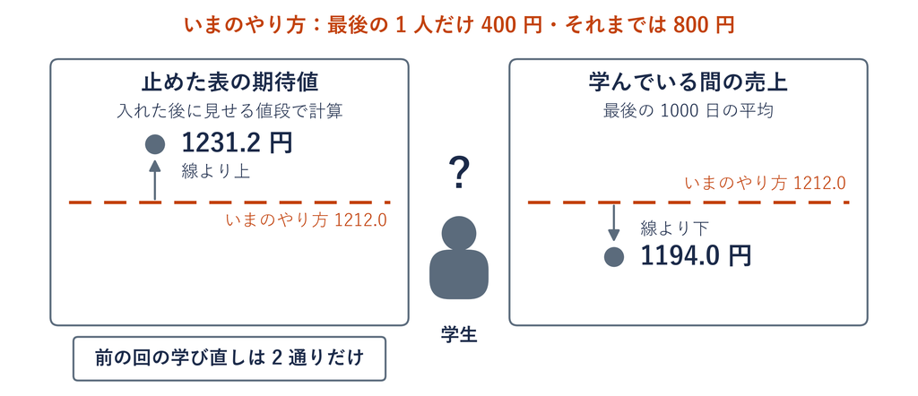

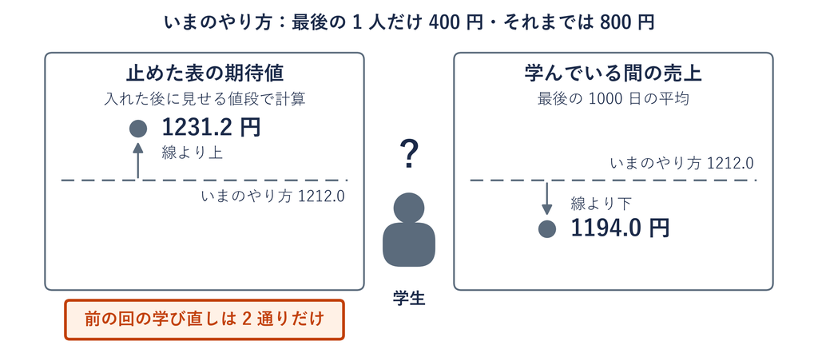

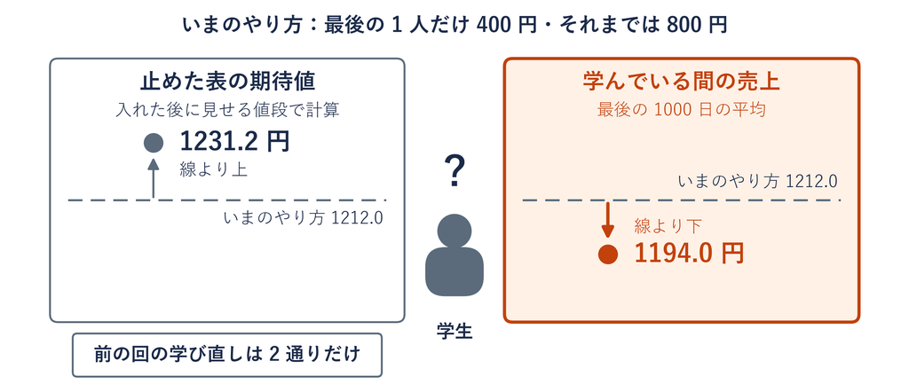

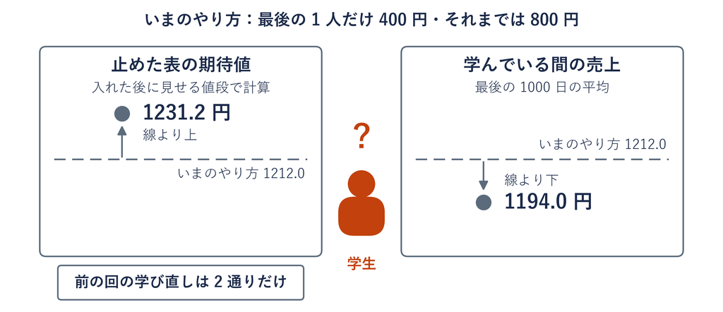

この店長を、うちの店に入れる？  
**①** 入れない **②** 入れる **③** まだ決められない

動画を止めて、①〜③から1つ選んで、少し考えてから再生

## 残り 1 人・在庫 1 個の 5 つの期待値

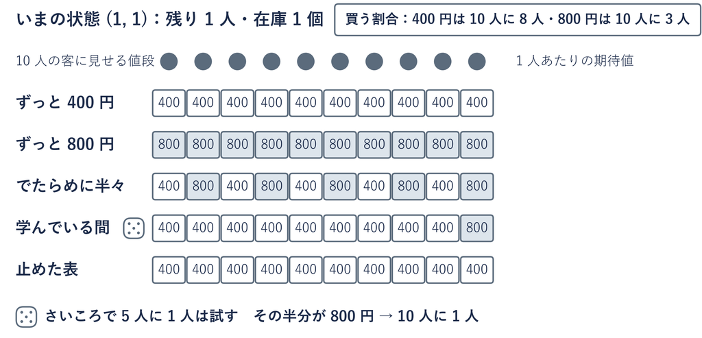

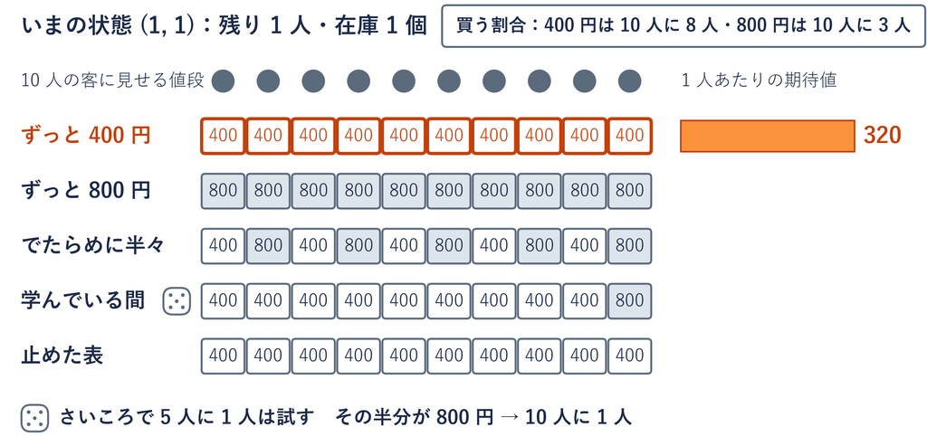

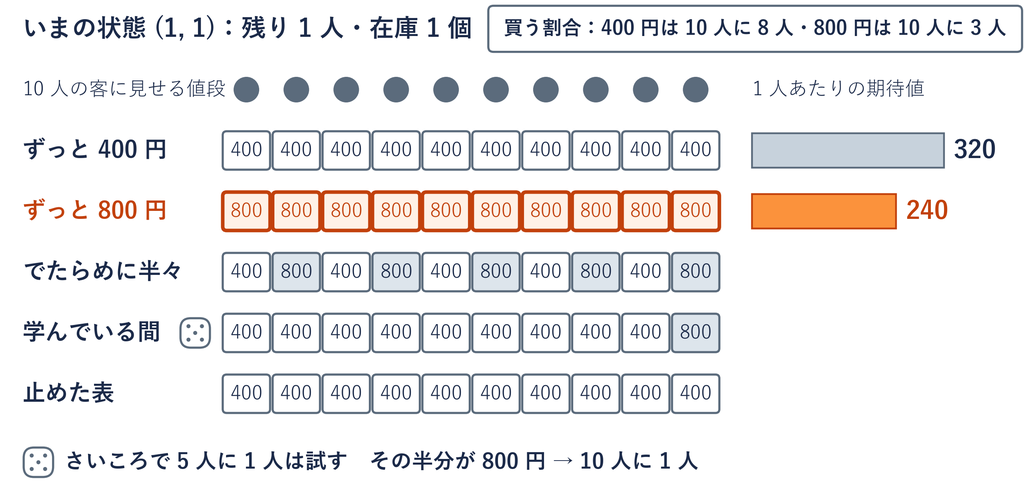

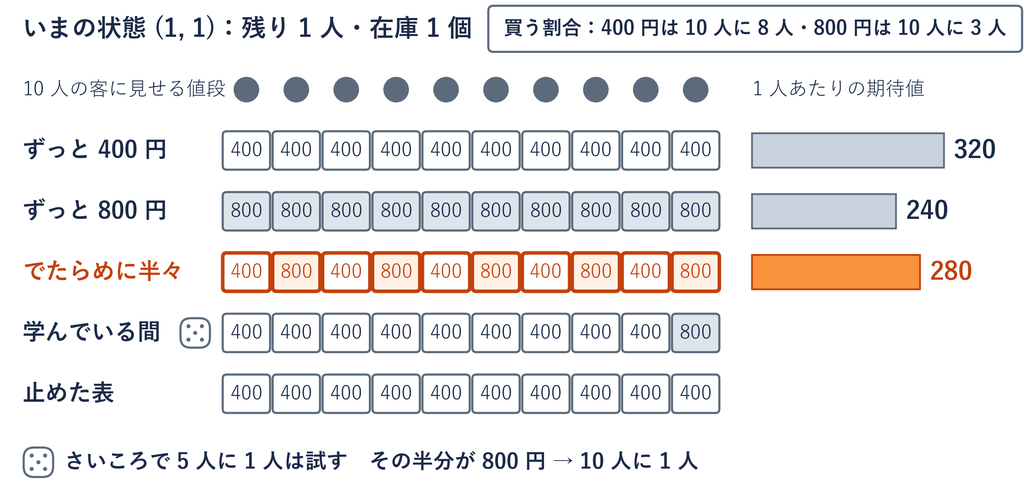

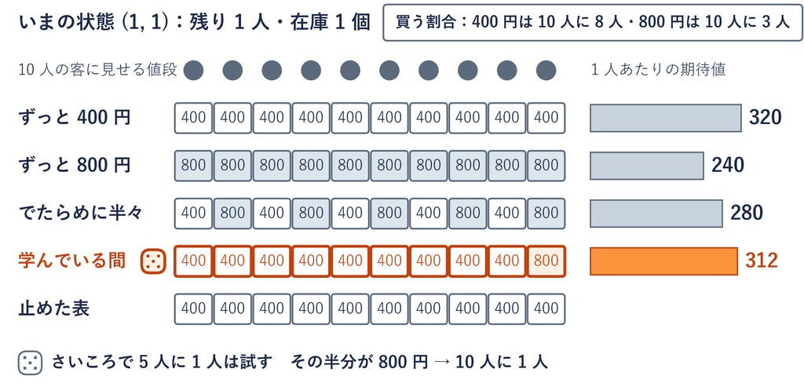

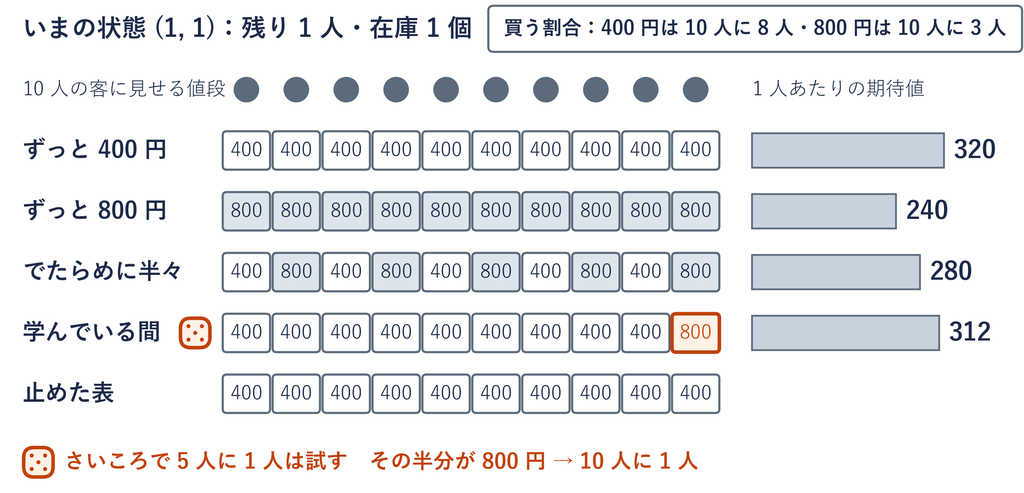

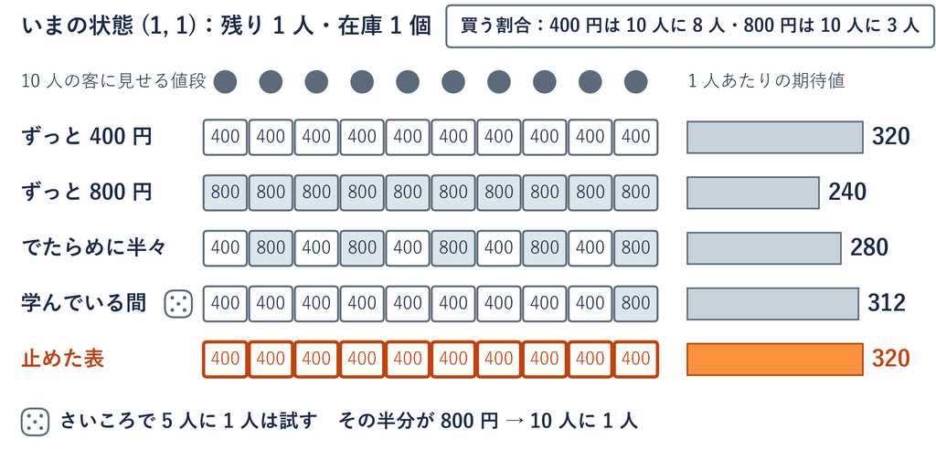

入れた後は、試すのも学ぶのも止める  
だから、まず何を測るかを先に決める

## うちの店の 3 つの数

今度はうちの店（客 6 人・在庫 2 個）で、学生の店長（客の並び seed 42・5000 日）

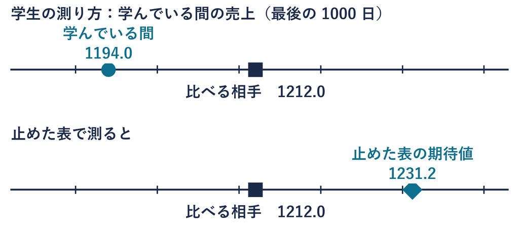

**天井** 1231.2 円  
閉店の側から逆算した表の期待値  
どの決め方も、これより高くならない  
仕組みが分かる店で、道具を確かめる物差し

でたらめに半々 978.7 円と比べると  
252.5 円多く見える

前に見た事前登録：測る数を後から選ぶと、結論も選べてしまう

## 回す前に決めるもの

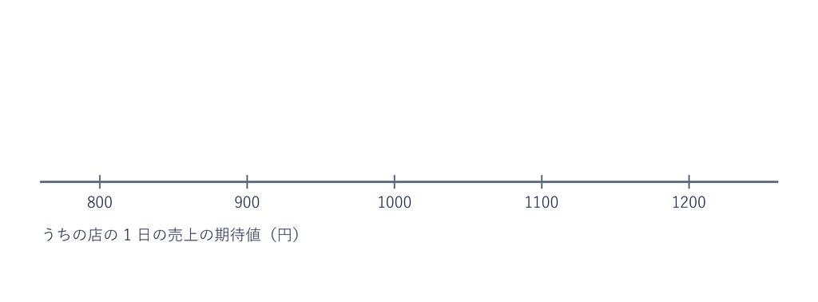

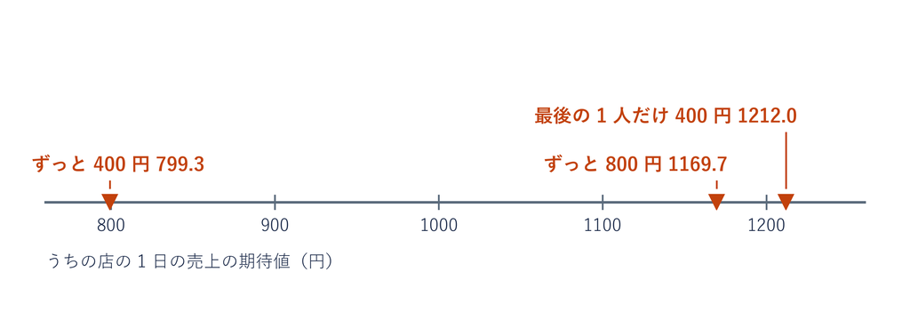

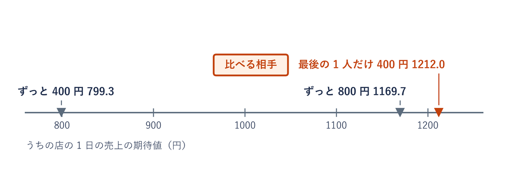

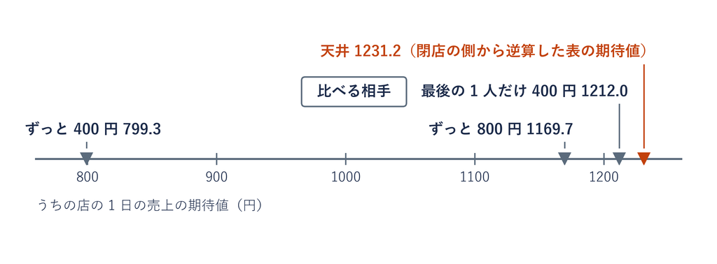

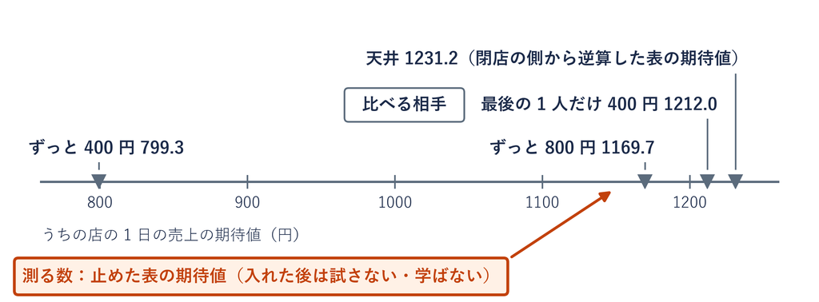

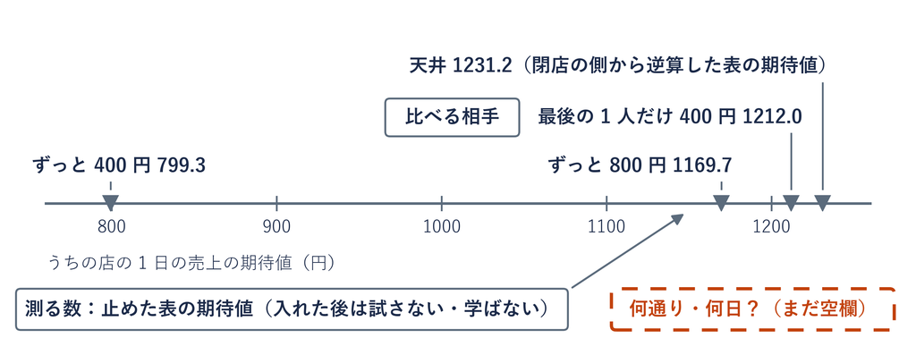

**比べる相手と天井を、先に決める**

測り方：計算機の中は設定から正確に／本物の店は、学ぶのと別の日の試し売りで

基準方策：比べる相手の学術名（前に見た基準条件と事前登録）

## 5 通りの学び直しと学ぶ日数

学生の問い：100 通りで確かめたい。5000 日は時間がかかる。100 日でもよいか

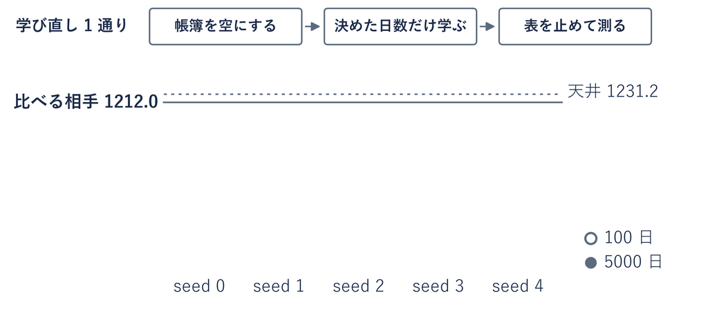

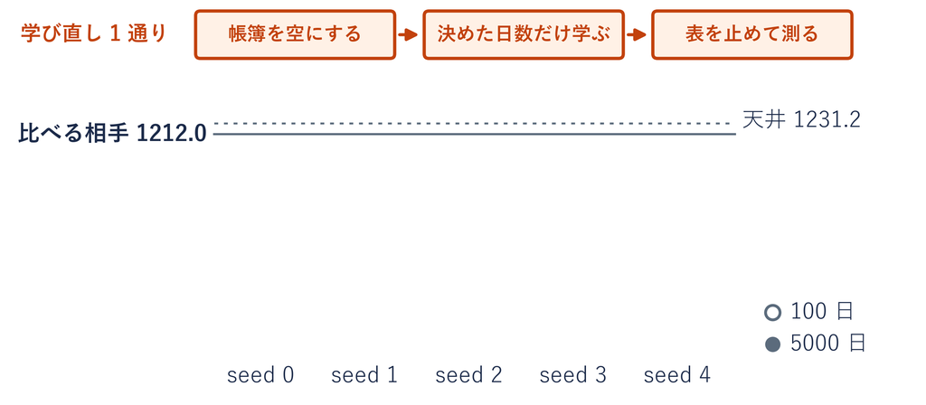

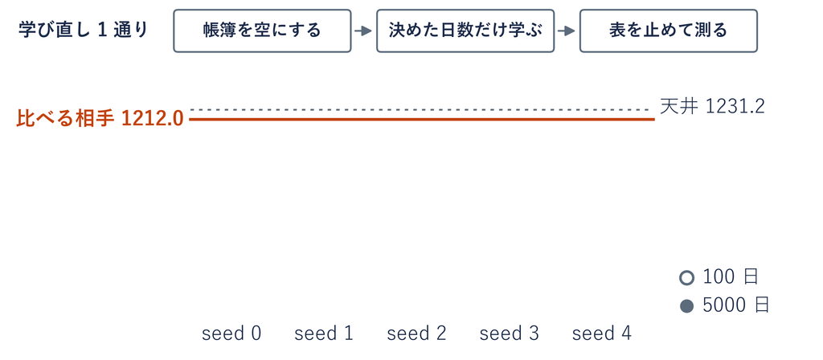

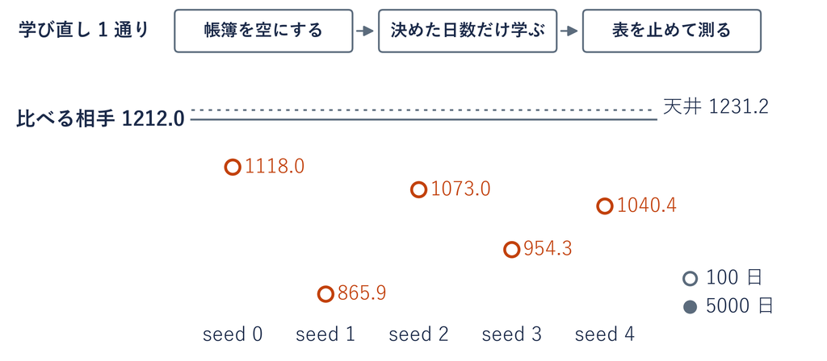

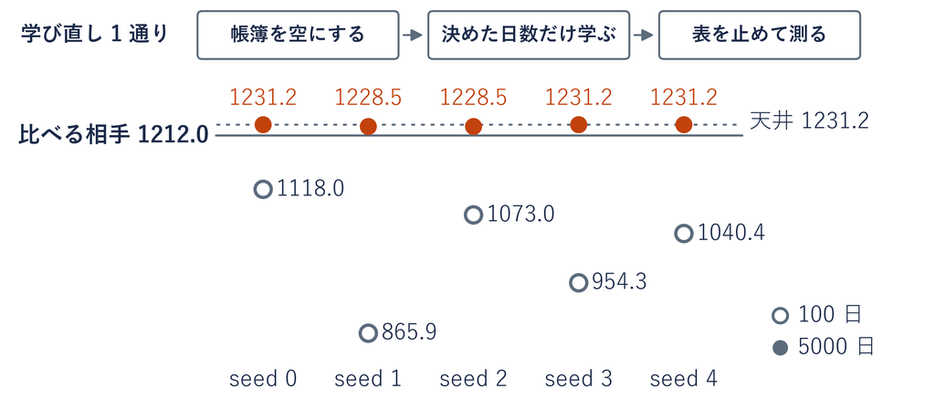

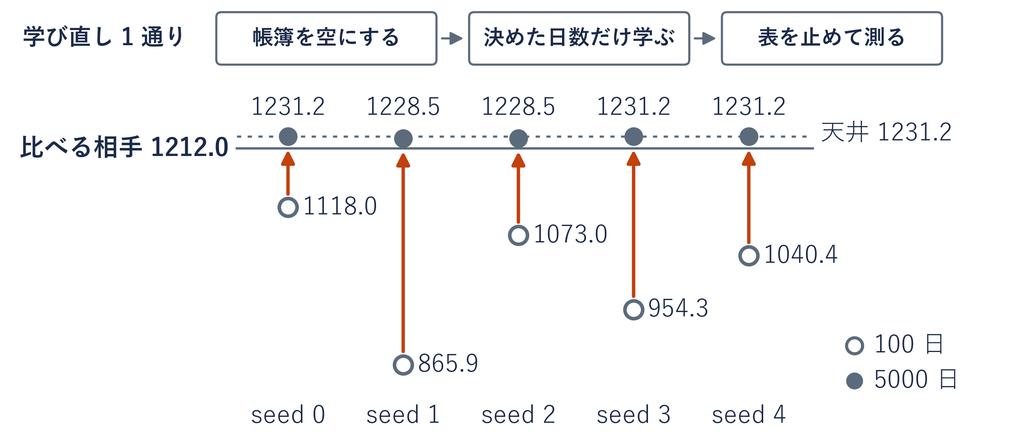

100 日は 5 通りとも下、5000 日は 5 通りとも上。日数で結論が逆

## 学び直し 100 通りと学ぶ日数

何通り・何日？ → **100 通り・5000 日**

[figure not shown]

5000 日なら 100 通りのうちの 100 通りが比べる相手を  
上回る（100 日では 4 通り）

経験量＝学ぶ日数（計算機の中で学ばせた営業日数）

学んでいる間の売上：100 通りとも 1212.0 円より下

## 日数のループの写経

準備のセルの `summary(店, 日数)` が、  
学び直し 100 通りを数えて返す（そのまま実行）

```python
for days in [100, 5000]:                 # 学ぶ日数を 2 つ
    s = summary("うちの店", days)        # 100 通りで数える
    print(days, s["上回った"], s["届いた"], s["最小"], s["最大"])
```

| 行 | 部品 | 中身 |
| --- | --- | --- |
| 1 | **① 日数を並べる** | 100 日と 5000 日を 1 つずつ days に入れる |
| 2 | **② 100 通りで数える** | うちの店で、 その日数だけ学ばせた 100 通りの数を s に受け取る |
| 3 | **③ 1 行で出す** | 日数・上回った数・届いた数・最小・最大 `s["上回った"]` は名前で数を引く |

## 日数のループの写経と実行

1. 上から準備のセルまで **▶**  
   **＋ コード**で足す
2. 前のページの 3 行を  
   上から写す
3. **▶** か Shift +  
   Enter で実行  
   （Mac は Shift + return・  
   数秒かかる）
4. 出力の 2 行で  
   4 通りと 100 通りを見る

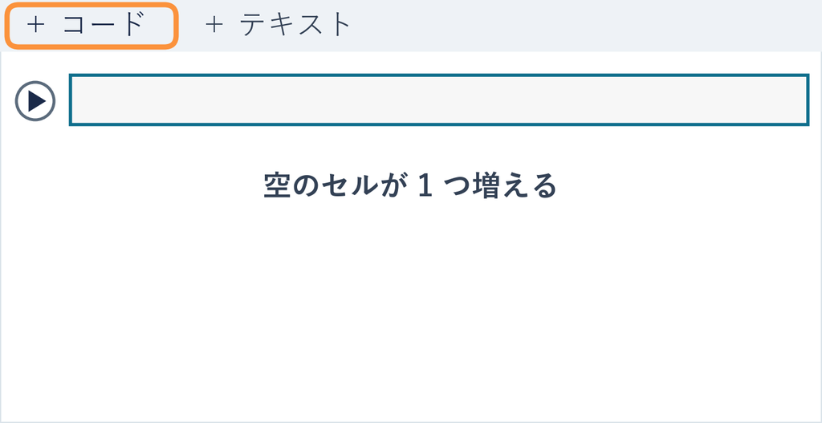

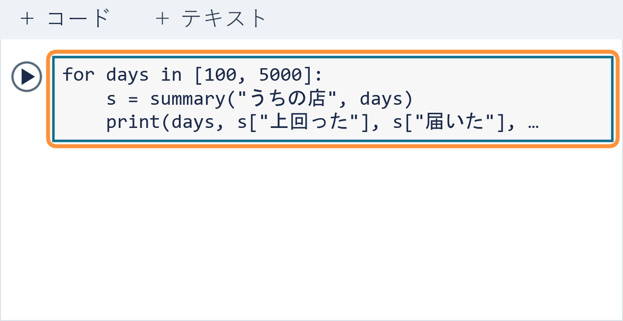

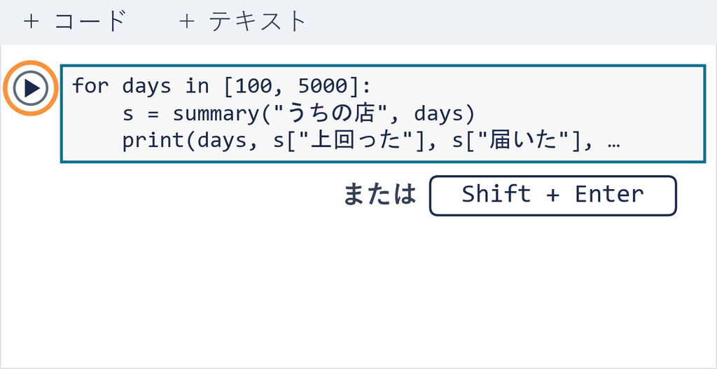

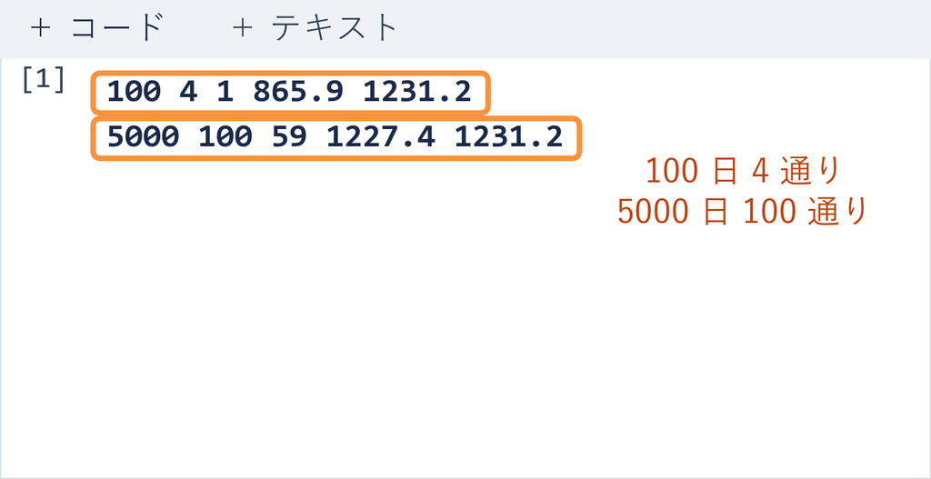

⏸ PAUSE 動画を止めて $3$ 分。2 行が出たら再生に戻る

## 演習1 日数の変更と測り方

写経の出力 100 日 4 通り・5000 日 100 通り

演習 1

1000 日の 81 通りを自分の手で出し、測り方を選ぶ

```python
for days in [100, 1000, 5000]:           # ← 1000 を足す
    s = summary("うちの店", days)
    print(days, s["上回った"], s["届いた"], s["最小"], s["最大"])
```

1. **再現する**：写経のセルを写し、並びに `1000` を足す（1 か所）。最小が 1212.0 より下か上かを見る
2. **選ぶ**：友だちのカフェのランチの値引きを確かめるなら？  
   比べる相手（① 何もしない日 ② いまの値引き）／測り方（① 学んでいる間の売上 ② 止めて別の日の試し売り）
3. **終わり**：3 行が出たら、答え欄に 1000 日の数と範囲、選んだ番号を書く

⏸ PAUSE 動画を止めて $5$ 分。書いたら再生に戻る

## 演習1の答え

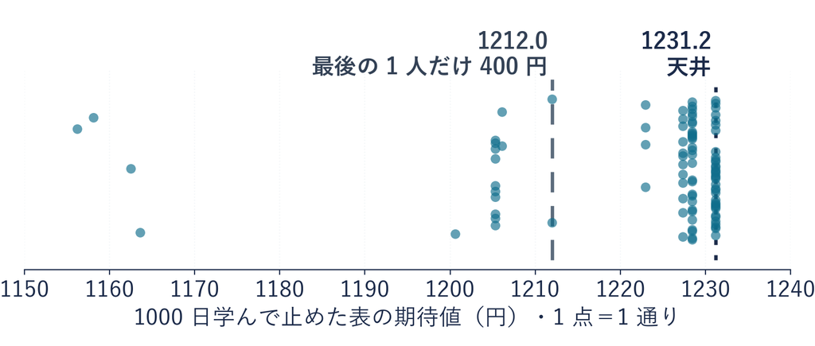

- **答え**：真ん中の 1 行 `1000 81 36 1156.2 1231.2`  
  上回った 81 通り・範囲 1156.2〜1231.2 円
- **読み**：最小は 1212.0 より下。1000 日では、まだ 5 通りに 1 通りくらいは上回らない
- **選ぶ**：比べる相手は ② いまの値引き・測り方は ② 止めて別の日の試し売り

## 在庫 1 個の店での学習

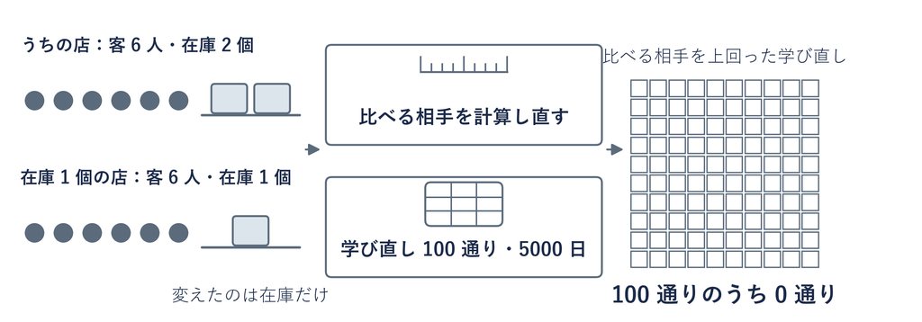

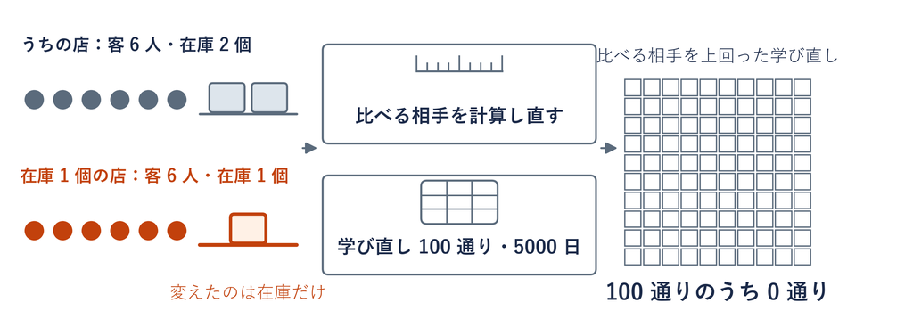

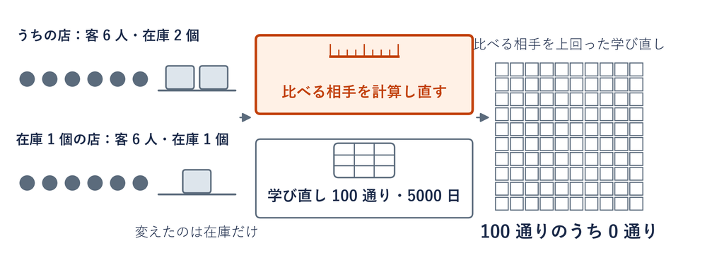

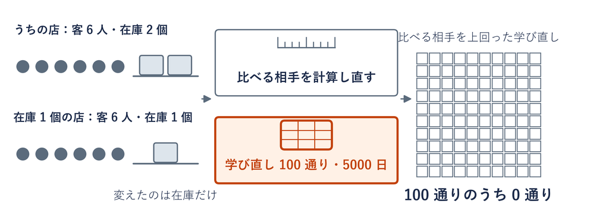

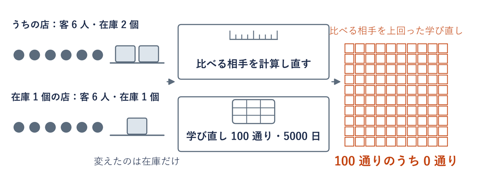

この店では、強化学習の店長は？  
**①** 失敗 **②** 店が悪い **③** 天井と比べるまで分からない

見当を付けてから、次のページで確かめる

## 2 つの店の天井と比べる相手

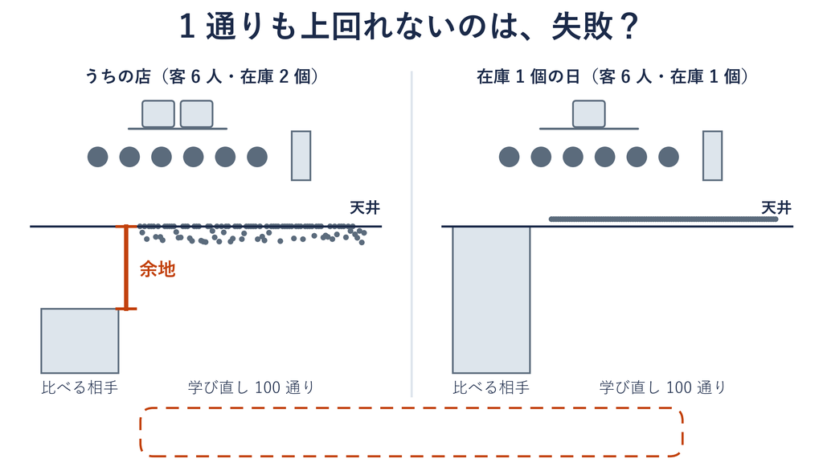

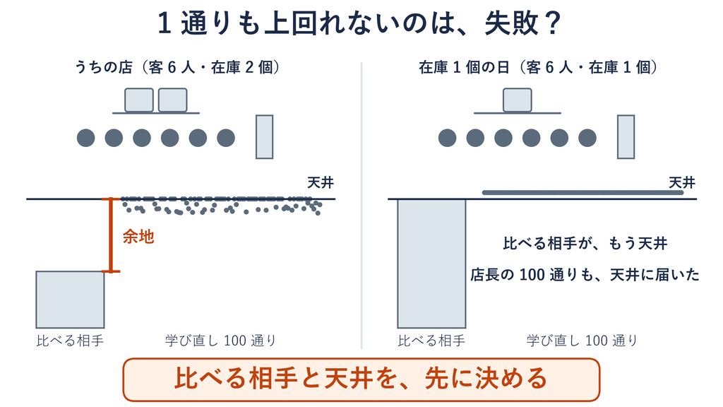

## 上回れる余地と 6 つの店

定義

**上回れる余地**この店の天井から、比べる相手の期待値を引いた差

学習で上乗せできる、1 日の売上の期待値の上限  
余地が 0 でも、店長が天井に届いたとは限らない（数で別に数える）

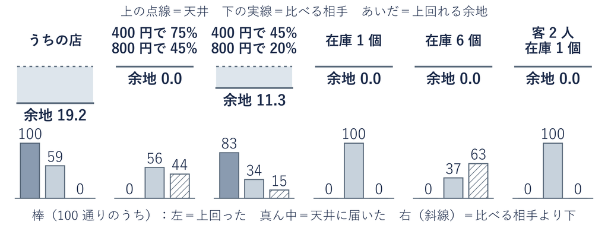

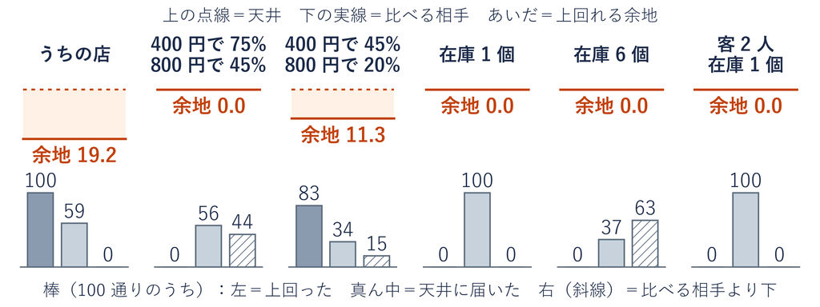

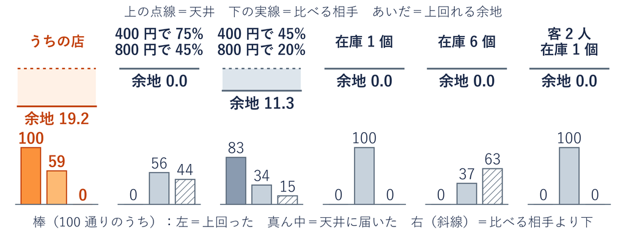

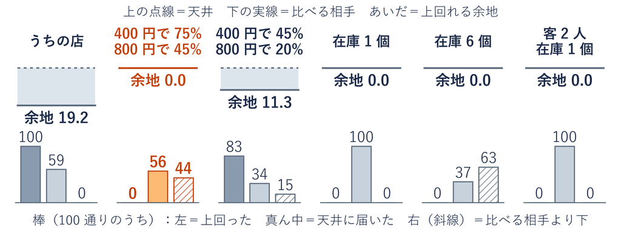

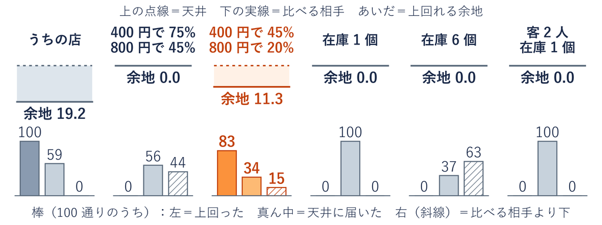

## デモ 比べる：店を変える

数の話

上回れる余地：天井 − 比べる相手（いちばん強い単純なルール）

- **何を見るか**：6 つの店の単純なルールと天井、学び直し 100 通りの止めた表の期待値
- **図の意味**：上＝4 本の棒・下＝100 通りの点（拡大）
- **操作**：店のボタンで条件を 1 つだけ変える

配布デモ lecture13_compare_demo.html（manaba の第 13 回の資料）の  
「店を変える」タブでも試せる

※ 次のスライドへ進むときは、デモの枠の外を一度クリックしてから ← → キーを押す

[interactive chart not shown]

## まとめ

疑問 学んでいる間に売上が下回った。入れないほうがいい？

回答 まだ決めない。入れる前に、  
比べる相手と天井を先に決めて数える  
天井が分からない広い店でも、  
比べる相手と測り方は先に決められる

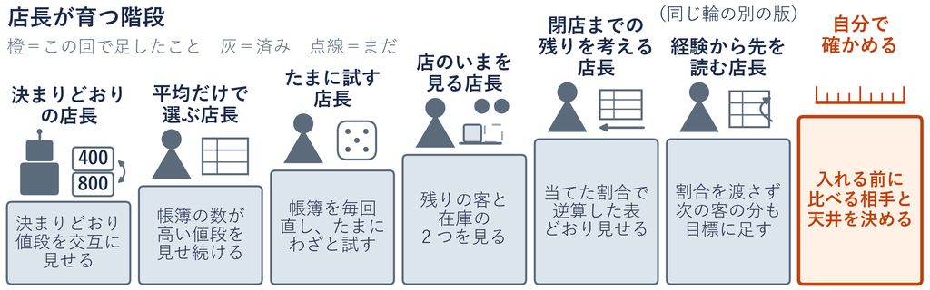

やること：小課題ノートの写経と演習 1・答えの欄を仕上げて、manaba へ

## 物語の始まりと終わり

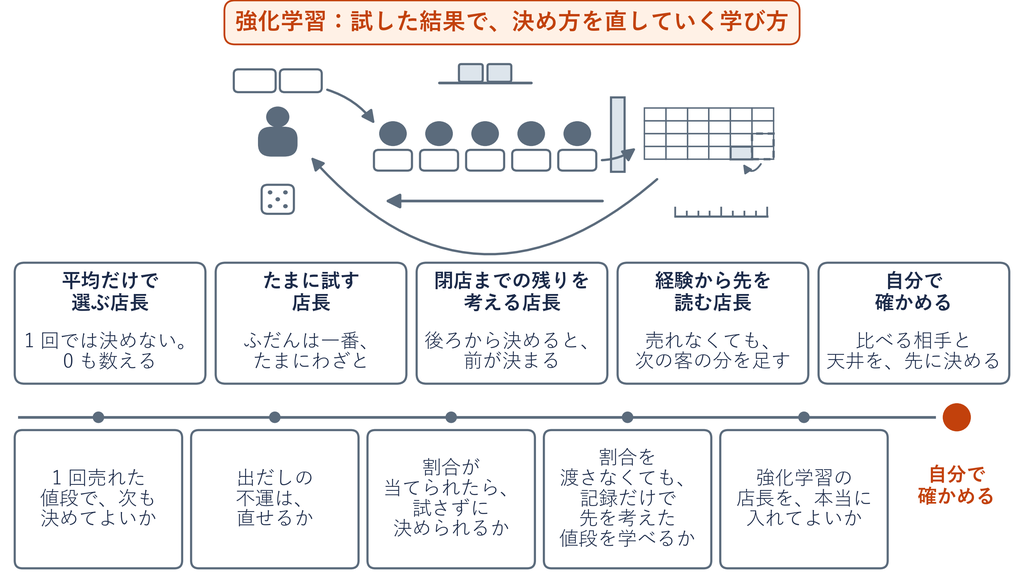

## 科目の 1 文

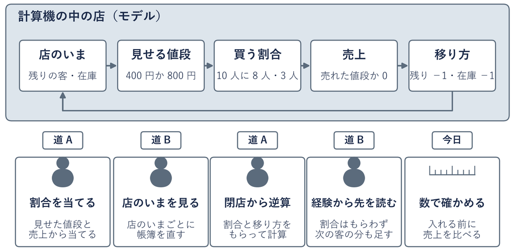

**人の選び方をモデルにし、記録に合わせ、数で確かめる**